# Data Analysis with R Programming - How a Bikeshare Company Navigates Its Speedy Success

## Rides in times of day

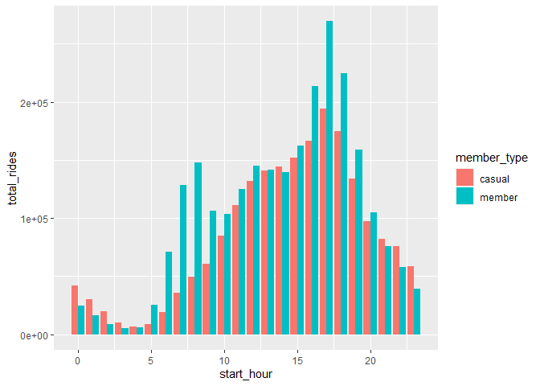

```r
all_trip %>%
  group_by(member_type, start_hour) %>%
  summarise(total_rides = n()) %>%
  ggplot(aes(start_hour, total_rides, fill = member_type)) +
  geom_col(position = "dodge")
```

### Top Stations for members to start their trips:

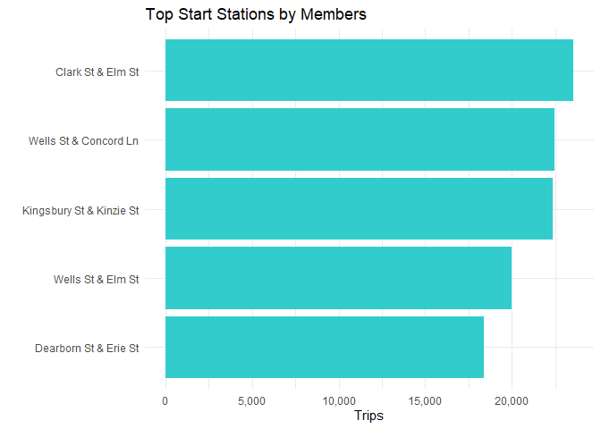

```r
all_trip %>%
  filter(member_type == 'member') %>%
  group_by(start_station_name) %>%
  summarise(trip_count = n()) %>%
  arrange(desc(trip_count)) %>%
  top_n(5) %>%
  ggplot(aes(x=trip_count, y=reorder(start_station_name, trip_count))) +
  geom_col(fill = "#33cccc") +
  labs(title = "Top Start Stations by Members", x="Trips", y=" ") +
  scale_x_continuous(labels = scales::comma) +
  theme_minimal()
```

### Top Stations for casual riders to begin their trips:

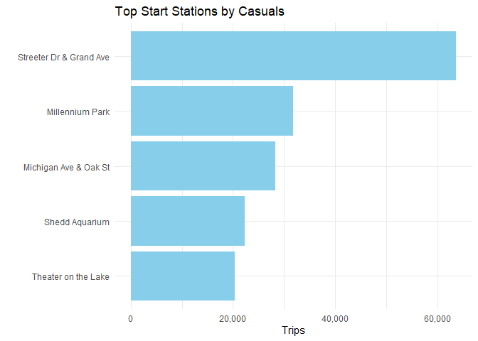

```r
all_trip %>%
  filter(member_type == 'casual') %>%
  group_by(start_station_name) %>%
  summarise(trip_count = n()) %>%
  arrange(desc(trip_count)) %>%
  top_n(5) %>%
  ggplot(aes(x=trip_count, y=reorder(start_station_name, trip_count))) +
  geom_col(fill = "sky blue") +
  labs(title = "Top Start Stations by Casuals", x="Trips", y=" ") +
  scale_x_continuous(labels = scales::comma) +
  theme_minimal()
```

### Member types and their bike preferences

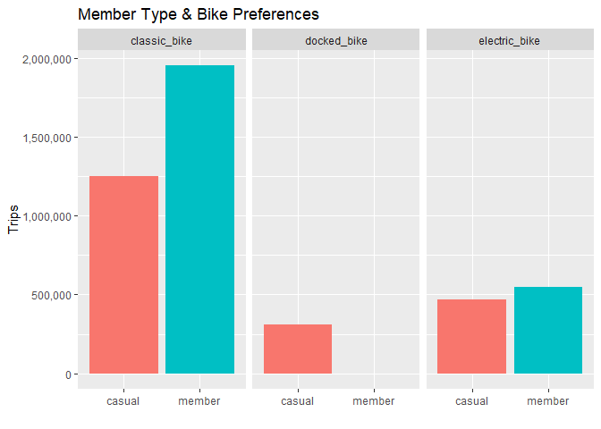

```r
all_trip %>%
  group_by(member_type, bike_type) %>%
  summarise(trip_count = n()) %>%
  ggplot(aes(member_type,trip_count, fill = member_type)) +
  geom_col(position = "dodge") +
  labs(title = "Member Type & Bike Preferences", x=" ", y = "Trips") +
  theme(legend.position = "none") +
  scale_y_continuous(labels = scales::comma) +
  facet_wrap(~bike_type)
```

## Key Findings:

- Casual riders on average spend more time with their bike on each trip compared with members.
- There are surges in the number of trips taken among members during rush hours in the morning and in the afternoon.
- Casuals’ trips are much more concentrated in the weekends whereas members’ rides are evenly distributed daily regardless of weekdays.
- Classic bikes remain the most popular Divvy bike type, with almost 2 millions members’ trips and approximately 1.25 millions trips by casual riders.
- Some of the busiest stations for casual riders are listed:
  - Streeter Dr & Grand Ave
  - Millennium Park
  - Michigan Ave. & Oak St

## Recommendations:

- Increase price for trips longer than 20 minutes to persuade casual riders switch to memberships.
- Add promotions on Friday, Saturday, and Sunday for riders with annual memberships so they can spend more time with their bike. This might result in less bikes available for casual riders in those days.
- Run marketing campaigns targeting areas concentrated with casual riders - vicinity around the top stations they most likely begin their trips.

## Export cleaned data into csv for further analysis in Tableau

```r
all_trip %>%
  select(-c(weekday, month, end_at, start_hour, date)) %>%
  write.csv(file = "all_trip.csv")
```

View this analysis visualization on my Tableau Dashboard [here](https://public.tableau.com/views/Book1_16409358660030/Dashboard1?:language=en-US&:display_count=n&:origin=viz_share_link)